# Kalibrationsänderung: SM2 → Neukalibrationen 2026 (Satz 1 & 2)

Author

Thomas Laepple

Published

July 7, 2026

```r
source("/Users/tlaepple/sharedAI/CalibrationRegistry/R/calib_registry.R")
NEWEV <- c("2026-07-06_set1", "2026-07-07_set2")
TEMPS <- c(0, -10, -20, -30)
cf <- function(row) setNames(as.numeric(row[c("a","b","c","d")]), c("a","b","c","d"))
r <- read_registry()

## newest usable NEW calibration per sensor (N98 is in both sets -> take latest)
newr <- r[r$cal_id %in% NEWEV & r$status %in% c("active","suspect"), ]
newr <- do.call(rbind, lapply(split(newr, newr$sensor),
          function(d) d[order(as.Date(d$cal_date)), ][nrow(d), ]))
old <- r[r$cal_id == "SM2", ]

## delta(T) = T_new - T_SM2 at a fixed resistance = how much the recalibration shifts the
## reported temperature at each true temperature. Positive = new reads WARMER (SM2 under-read).
rows <- list(); k <- 0
for (i in seq_len(nrow(newr))) {
  sn <- newr$sensor[i]; om <- old[old$sensor == sn, ]; if (!nrow(om)) next
  cn <- cf(newr[i, ]); co <- cf(om[1, ])
  d <- sapply(TEMPS, function(T) {
    R <- tryCatch(R_at_T(T, cn, c(1e3, 5e6)), error = function(e) NA)
    if (is.na(R)) NA else (T - predict_T(R, co)) * 1000
  })
  k <- k + 1
  rows[[k]] <- data.frame(sensor = sn, node = newr$node[i],
    set = ifelse(newr$cal_id[i] == NEWEV[1], "set1", "set2"),
    status = newr$status[i], d0 = d[1], d_10 = d[2], d_20 = d[3], d_30 = d[4])
}
D <- do.call(rbind, rows)
D <- D[order(D$set, as.integer(sub("N","",D$node)), D$sensor), ]
setcol <- c(set1 = "#1b9e77", set2 = "#d95f02")
```

## Was das ist

Vergleich der **alten** Kalibration (`SM2`, 15.06.2026, Nora Hirsch) mit den **neuen** zeit-gematchten Kalibrationen (`Satz 1` 06.07., `Satz 2` 07.07.). Gezeigt wird **ΔT = T_neu − T_SM2** bei denselben Widerstandswerten, ausgewertet bei **0, −10, −20, −30 °C** — also *wie stark sich die berichtete Temperatur pro Sensor durch die Neukalibration ändert*. Positiv = die neue Kalibration liest **wärmer** (SM2 hatte zu kalt gelesen).

## Zusammenfassung pro Temperatur

```r
tab <- data.frame(
  Temp_C = TEMPS,
  median_mK = sapply(c("d0","d_10","d_20","d_30"), function(n) round(median(D[[n]], na.rm=TRUE),1)),
  mean_mK   = sapply(c("d0","d_10","d_20","d_30"), function(n) round(mean(D[[n]], na.rm=TRUE),1)),
  min_mK    = sapply(c("d0","d_10","d_20","d_30"), function(n) round(min(D[[n]], na.rm=TRUE),1)),
  max_mK    = sapply(c("d0","d_10","d_20","d_30"), function(n) round(max(D[[n]], na.rm=TRUE),1)),
  n_gt20mK  = sapply(c("d0","d_10","d_20","d_30"), function(n) sum(abs(D[[n]])>20, na.rm=TRUE)))
knitr::kable(tab, row.names = FALSE,
  caption = "ΔT = T_neu − T_SM2 (mK). Der gemeinsame ~+10 mK-Versatz bei 0 °C schrumpft zur Kälte; die Streuung (min/max) wächst zur Kälte durch einzelne SM2-Kurvenfehler.")
```

ΔT = T_neu − T_SM2 (mK). Der gemeinsame ~+10 mK-Versatz bei 0 °C schrumpft zur Kälte; die Streuung (min/max) wächst zur Kälte durch einzelne SM2-Kurvenfehler.

| Temp_C | median_mK | mean_mK | min_mK | max_mK | n_gt20mK |
| --- | --- | --- | --- | --- | --- |
| 0 | 10.9 | 11.9 | 2.4 | 28.4 | 5 |
| -10 | 7.8 | 9.1 | 1.9 | 28.8 | 5 |
| -20 | 5.5 | 9.0 | -5.8 | 45.6 | 9 |
| -30 | 5.1 | 11.4 | -29.2 | 90.7 | 12 |

Kernbefund:

- **Gemeinsamer Versatz ~+10 mK bei 0 °C** über fast alle Sensoren (SM2 las am warmen Ende systematisch zu kalt) — der Großteil der Korrektur.
- **Eine Minderheit von Kanälen** (v. a. `TestSB` + einige `NTC1`) hatte **große, zur Kälte wachsende SM2-Kurvenfehler**, bis **~+90 mK bei −30 °C**.

## Grafik 1 — ΔT über die Temperatur (alle Kanäle)

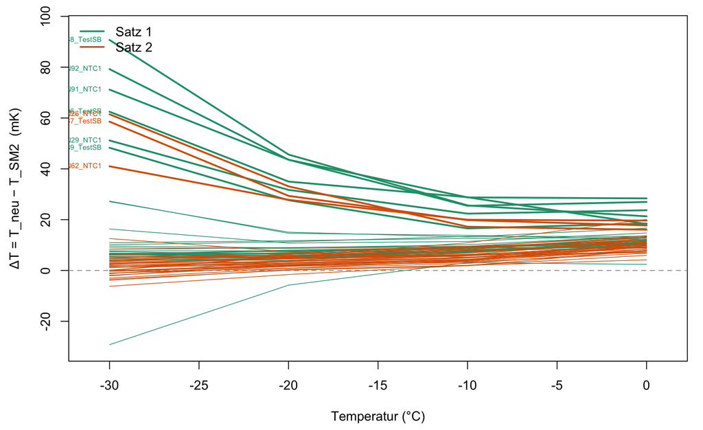

Jede Linie = ein NTC-Kanal. Gut kalibrierte Kanäle laufen zur Kälte zusammen (~+5 mK); die Ausreißer fächern nach oben auf.

```r
par(mar=c(4.4,4.4,1,1))
yl <- range(c(D$d0,D$d_10,D$d_20,D$d_30), na.rm=TRUE)*1.05
plot(NA, xlim=c(-31,1), ylim=yl, xlab="Temperatur (°C)", ylab="ΔT = T_neu − T_SM2  (mK)")
abline(h=0, lty=2, col="grey60")
for (i in seq_len(nrow(D))) {
  y <- as.numeric(D[i,c("d0","d_10","d_20","d_30")])
  big <- max(abs(y),na.rm=TRUE) > 30
  lines(TEMPS, y, col=setcol[D$set[i]], lwd=if(big)2.2 else 0.8)
  if (big) text(-30, y[4], D$sensor[i], pos=2, cex=.55, col=setcol[D$set[i]])
}
legend("topleft", c("Satz 1","Satz 2"), col=setcol, lwd=2, bty="n")
```

## Grafik 2 — Verteilung bei jeder Temperatur

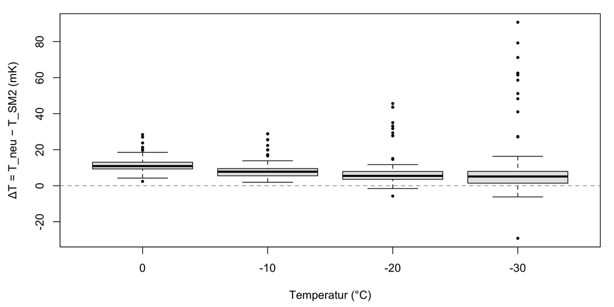

Median ~+10 mK bei 0 °C, zur Kälte kleiner werdend; die Ausreißer-Schwänze (einzelne Kanäle) wachsen zur Kälte.

```r
par(mar=c(4.4,4.4,1,1))
boxplot(list(`0`=D$d0, `-10`=D$d_10, `-20`=D$d_20, `-30`=D$d_30),
  ylab="ΔT = T_neu − T_SM2 (mK)", xlab="Temperatur (°C)", col="grey90", outpch=16, outcex=.6)
abline(h=0, lty=2, col="grey60")
```

## Grafik 3 — Größte Korrekturen bei −30 °C

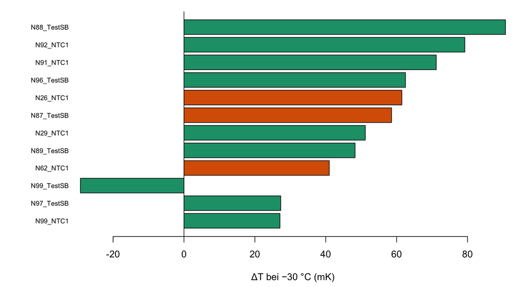

Top-Kanäle nach |ΔT| bei −30 °C — hier war SM2 am stärksten falsch.

```r
top <- head(D[order(-abs(D$d_30)), ], 12)
par(mar=c(4.4,7,1,1))
barplot(rev(top$d_30), horiz=TRUE, names.arg=rev(top$sensor), las=1, cex.names=.7,
  col=rev(setcol[top$set]), xlab="ΔT bei −30 °C (mK)"); abline(v=0)
```

```r
knitr::kable(top[,c("sensor","set","status","d0","d_10","d_20","d_30")], row.names=FALSE,
  digits=1, caption="Kanäle mit den größten SM2-Kurvenfehlern (ΔT in mK).")
```

Kanäle mit den größten SM2-Kurvenfehlern (ΔT in mK).

| sensor | set | status | d0 | d_10 | d_20 | d_30 |
| --- | --- | --- | --- | --- | --- | --- |
| N88_TestSB | set1 | active | 21.3 | 25.6 | 45.6 | 90.7 |
| N92_NTC1 | set1 | active | 27.0 | 25.4 | 43.6 | 79.2 |
| N91_NTC1 | set1 | active | 28.4 | 28.8 | 43.6 | 71.2 |
| N96_TestSB | set1 | active | 18.3 | 28.8 | 35.0 | 62.5 |
| N26_NTC1 | set2 | suspect | 16.0 | 17.2 | 33.1 | 61.5 |
| N87_TestSB | set2 | active | 17.8 | 19.8 | 29.4 | 58.6 |
| N29_NTC1 | set1 | active | 23.7 | 22.4 | 31.7 | 51.2 |
| N89_TestSB | set1 | active | 18.5 | 16.5 | 27.7 | 48.3 |
| N62_NTC1 | set2 | active | 19.6 | 20.0 | 27.8 | 41.0 |
| N99_TestSB | set1 | active | 2.4 | 3.1 | -5.8 | -29.2 |
| N97_TestSB | set1 | active | 12.2 | 13.8 | 14.6 | 27.3 |
| N99_NTC1 | set1 | active | 16.7 | 13.2 | 15.1 | 27.1 |

## Zwischenchecks: N94 & N96 haben einen dritten (und vierten) Punkt

Für **N94** und **N96** existieren unabhängige Zwischenmessungen als Residuum-zu-SM2: `ntc2test` (**01.07., −20 °C**) und `recalib2sensors` (**03.07., −14 °C**). Damit lässt sich die Trajektorie **SM2 (15.06.) → 01.07. → 03.07. → Satz 1 (06.07.)** zeichnen und unterscheiden, ob eine Abweichung ein **stabiler SM2-Kurvenfehler** oder eine **Drift** ist.

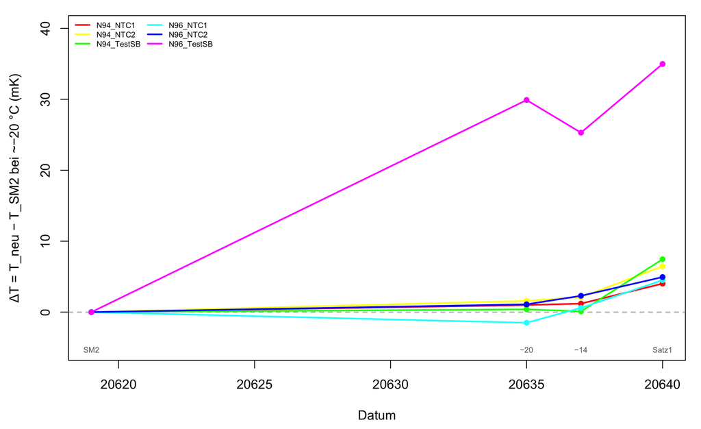

Abweichung von SM2 über die Zeit bei ~−20 °C. Flach = stabiler SM2-Kurvenfehler; steigend = Drift. NTC3 = TestSB.

```r
rep <- read.csv("/Users/tlaepple/sharedAI/CalibrationChains/recalib2sensors/Repro_vs_ntc2test.csv",
                stringsAsFactors=FALSE)
rep$sensor <- sub("NTC3","TestSB", rep$NTC)
## delta(new - SM2) = -(SM2 bias). ntc2test @ -20, recalib2sensors @ -14.
rep$t01 <- -rep$bias_m20_ntc2test      # 2026-07-01 @ -20 C
rep$t03 <- -rep$bias_m14_mK            # 2026-07-03 @ -14 C
dt <- as.Date(c("2026-06-15","2026-07-01","2026-07-03","2026-07-06"))
par(mar=c(4.4,4.4,1,1))
sens <- rep$sensor; cols <- rainbow(length(sens))
plot(NA, xlim=range(dt), ylim=range(c(0,rep$t01,rep$t03,40,-5)), xlab="Datum",
     ylab="ΔT = T_neu − T_SM2 bei ~−20 °C (mK)")
abline(h=0, lty=2, col="grey60")
for (i in seq_along(sens)) {
  d20_set1 <- D$d_20[D$sensor==sens[i]]                     # set1 @ -20
  y <- c(0, rep$t01[i], rep$t03[i], if(length(d20_set1)) d20_set1 else NA)
  lines(dt, y, col=cols[i], lwd=2); points(dt, y, col=cols[i], pch=16)
}
legend("topleft", sens, col=cols, lwd=2, cex=.6, bty="n", ncol=2)
text(dt, par("usr")[3], c("SM2","−20","−14","Satz1"), pos=3, cex=.6, col="grey40")
```

```r
it <- data.frame(sensor=rep$sensor,
  SM2=0, chk_0701_m20=round(rep$t01,1), chk_0703_m14=round(rep$t03,1),
  set1_m20=round(sapply(rep$sensor,function(s){v<-D$d_20[D$sensor==s]; if(length(v))v else NA}),1))
knitr::kable(it, row.names=FALSE, caption="N94/N96: ΔT (T_neu − T_SM2) über die Zeit. Alle N94-Kanäle und N96_NTC1/2 liegen stabil um 0; N96_TestSB liegt konstant bei ~+25…+35 mK → das ist ein STABILER SM2-Kurvenfehler, keine Drift.")
```

N94/N96: ΔT (T_neu − T_SM2) über die Zeit. Alle N94-Kanäle und N96_NTC1/2 liegen stabil um 0; N96_TestSB liegt konstant bei ~+25…+35 mK → das ist ein STABILER SM2-Kurvenfehler, keine Drift.

| sensor | SM2 | chk_0701_m20 | chk_0703_m14 | set1_m20 |
| --- | --- | --- | --- | --- |
| N94_NTC1 | 0 | 1.0 | 1.2 | 4.0 |
| N94_NTC2 | 0 | 1.6 | 2.1 | 6.5 |
| N94_TestSB | 0 | 0.4 | 0.1 | 7.5 |
| N96_NTC1 | 0 | -1.5 | 0.6 | 4.5 |
| N96_NTC2 | 0 | 1.1 | 2.3 | 4.9 |
| N96_TestSB | 0 | 29.9 | 25.3 | 35.0 |

**Schluss aus den Zwischenchecks:** N96_TestSB weicht seit dem 1. Juli konstant um **~+25…+35 mK** von SM2 ab (unabhängig gemessen an drei Terminen) — also ein **stabiler SM2-Kalibrierfehler**, keine sich entwickelnde Sensordrift. Alle N94-Kanäle und N96_NTC1/NTC2 sind über die Zeit stabil nahe SM2. (Kontrast: N26 in Satz 2 driftet *innerhalb* des Laufs → dort ist es echte Instabilität, siehe `N26_drift.pdf`.)

## Vollständige Tabelle

```r
knitr::kable(D[,c("sensor","set","status","d0","d_10","d_20","d_30")], row.names=FALSE, digits=1,
  caption="ΔT = T_neu − T_SM2 (mK) je Kanal bei 0/−10/−20/−30 °C.")
```

ΔT = T_neu − T_SM2 (mK) je Kanal bei 0/−10/−20/−30 °C.

| sensor | set | status | d0 | d_10 | d_20 | d_30 |
| --- | --- | --- | --- | --- | --- | --- |
| N29_NTC1 | set1 | active | 23.7 | 22.4 | 31.7 | 51.2 |
| N29_NTC2 | set1 | active | 13.1 | 8.7 | 6.3 | 7.4 |
| N29_TestSB | set1 | active | 10.3 | 7.3 | 5.4 | 5.7 |
| N88_NTC1 | set1 | active | 10.7 | 7.5 | 5.7 | 6.3 |
| N88_NTC2 | set1 | active | 10.0 | 8.0 | 6.7 | 6.8 |
| N88_TestSB | set1 | active | 21.3 | 25.6 | 45.6 | 90.7 |
| N89_NTC1 | set1 | active | 11.4 | 7.0 | 4.9 | 5.2 |
| N89_NTC2 | set1 | active | 10.9 | 9.0 | 7.8 | 7.7 |
| N89_TestSB | set1 | active | 18.5 | 16.5 | 27.7 | 48.3 |
| N90_NTC1 | set1 | active | 12.4 | 8.3 | 5.9 | 6.3 |
| N90_NTC2 | set1 | active | 11.8 | 7.5 | 5.3 | 5.2 |
| N90_TestSB | set1 | active | 10.8 | 9.5 | 9.0 | 8.2 |
| N91_NTC1 | set1 | active | 28.4 | 28.8 | 43.6 | 71.2 |
| N91_NTC2 | set1 | active | 13.6 | 10.1 | 8.9 | 9.6 |
| N91_TestSB | set1 | active | 13.0 | 12.6 | 11.7 | 10.9 |
| N92_NTC1 | set1 | active | 27.0 | 25.4 | 43.6 | 79.2 |
| N92_NTC2 | set1 | active | 11.0 | 9.3 | 6.8 | 6.3 |
| N92_TestSB | set1 | active | 13.4 | 13.4 | 11.3 | 10.1 |
| N93_NTC1 | set1 | active | 14.8 | 11.4 | 10.8 | 16.3 |
| N93_NTC2 | set1 | active | 10.1 | 9.2 | 7.5 | 6.7 |
| N93_TestSB | set1 | active | 8.7 | 9.2 | 8.0 | 6.4 |
| N94_NTC1 | set1 | active | 10.9 | 6.8 | 4.0 | 4.1 |
| N94_NTC2 | set1 | active | 11.6 | 8.9 | 6.5 | 6.1 |
| N94_TestSB | set1 | active | 9.3 | 8.9 | 7.5 | 6.5 |
| N96_NTC1 | set1 | active | 11.3 | 7.7 | 4.5 | 4.2 |
| N96_NTC2 | set1 | active | 9.1 | 7.7 | 4.9 | 3.9 |
| N96_TestSB | set1 | active | 18.3 | 28.8 | 35.0 | 62.5 |
| N97_NTC1 | set1 | active | 13.2 | 8.3 | 5.2 | 5.3 |
| N97_NTC2 | set1 | active | 11.8 | 9.5 | 6.8 | 6.1 |
| N97_TestSB | set1 | active | 12.2 | 13.8 | 14.6 | 27.3 |
| N99_NTC1 | set1 | active | 16.7 | 13.2 | 15.1 | 27.1 |
| N99_NTC2 | set1 | active | 10.9 | 7.8 | 5.4 | 5.1 |
| N99_TestSB | set1 | active | 2.4 | 3.1 | -5.8 | -29.2 |
| N13_NTC1 | set2 | active | 10.4 | 4.9 | 2.2 | 0.0 |
| N13_NTC2 | set2 | active | 8.9 | 5.8 | 3.5 | 1.1 |
| N13_TestSB | set2 | active | 11.9 | 8.8 | 6.3 | 4.1 |
| N18_NTC1 | set2 | active | 12.0 | 7.0 | 3.9 | 1.6 |
| N18_NTC2 | set2 | active | 12.8 | 8.6 | 5.1 | 2.4 |
| N18_TestSB | set2 | active | 12.1 | 9.2 | 6.3 | 3.8 |
| N19_NTC1 | set2 | active | 11.9 | 6.2 | 3.4 | 2.1 |
| N19_NTC2 | set2 | active | 11.3 | 7.2 | 4.5 | 2.7 |
| N19_TestSB | set2 | active | 10.5 | 8.2 | 5.9 | 3.5 |
| N25_NTC1 | set2 | active | 10.5 | 5.8 | 4.5 | 6.5 |
| N25_NTC2 | set2 | active | 9.8 | 4.4 | 2.7 | 1.7 |
| N25_TestSB | set2 | active | 13.2 | 9.5 | 7.1 | 4.7 |
| N26_NTC1 | set2 | suspect | 16.0 | 17.2 | 33.1 | 61.5 |
| N26_NTC2 | set2 | suspect | 7.7 | 5.2 | 7.4 | 12.6 |
| N26_TestSB | set2 | suspect | 4.2 | 2.0 | -1.6 | -6.2 |
| N28_NTC1 | set2 | active | 7.9 | 1.9 | 0.1 | -3.5 |
| N28_TestSB | set2 | active | 20.1 | 10.9 | 5.5 | 0.0 |
| N35_NTC1 | set2 | active | 8.4 | 3.4 | 1.7 | -1.9 |
| N35_NTC2 | set2 | active | 6.0 | 2.0 | 0.4 | -3.9 |
| N35_TestSB | set2 | active | 7.4 | 5.1 | 2.8 | -2.1 |
| N62_NTC1 | set2 | active | 19.6 | 20.0 | 27.8 | 41.0 |
| N62_NTC2 | set2 | active | 10.2 | 6.0 | 3.7 | -1.3 |
| N62_TestSB | set2 | active | 10.6 | 7.8 | 5.7 | 0.1 |
| N85_NTC1 | set2 | active | 7.9 | 2.8 | 0.8 | -3.0 |
| N85_NTC2 | set2 | active | 9.7 | 4.0 | 1.8 | -1.1 |
| N85_TestSB | set2 | active | 7.7 | 4.3 | 2.0 | -0.4 |
| N86_NTC1 | set2 | active | 9.3 | 3.8 | 2.1 | 1.2 |
| N86_NTC2 | set2 | active | 10.4 | 4.1 | 2.4 | 1.8 |
| N86_TestSB | set2 | active | 10.0 | 6.1 | 4.6 | 3.2 |
| N87_NTC1 | set2 | active | 9.1 | 5.2 | 3.0 | 1.2 |
| N87_NTC2 | set2 | active | 8.3 | 6.4 | 4.7 | 2.8 |
| N87_TestSB | set2 | active | 17.8 | 19.8 | 29.4 | 58.6 |
| N95_NTC1 | set2 | active | 9.3 | 3.8 | 0.9 | -1.0 |
| N95_NTC2 | set2 | active | 6.8 | 3.3 | 1.6 | 0.0 |
| N95_TestSB | set2 | active | 7.0 | 6.1 | 5.2 | 4.6 |
| N98_NTC1 | set2 | active | 13.7 | 9.5 | 8.6 | 8.9 |
| N98_NTC2 | set2 | active | 10.4 | 5.1 | 3.6 | 2.7 |
| N98_TestSB | set2 | active | 9.7 | 6.0 | 5.9 | 5.6 |

## Hinweise

- ΔT ist bezogen auf die **neue** Kalibration als Referenz (wir vertrauen der zeit-gematchten Neukalibration, U=2u ~1.8 mK Satz 1 / ~2.7 mK Satz 2).
- `SM2` (15.06.) ist das gemeinsame Alt-Referenzdatum; Operator Nora Hirsch.
- N98 ist in beiden neuen Sätzen; hier zählt die aktive Satz-2-Kalibration (Satz 1 war faulty).
- Zwischenchecks sind Einzeltemperatur-Residuen (nur bei ~−20/−14 °C für N94/N96), keine vollen Kurven.